# Mortgage Loans

**How many defaults might we expect?**

Let's say a bank made $100$ mortgage loans. It is possible that anywhere between $0$ and $100$ of the loans will be defaulted upon. You would like to know the probability of getting a given number of defaults, given that the probability of a default is $p = 0.05$.

**Monte Carlo Simulation**

1. To investigate this, you will do a simulation.
2. You will perform 100 Bernoulli trials and record how many defaults you get.
3. Here, a success is a default. (Remember that the word "success" just means that the Bernoulli trial evaluates to True, i.e., did the loan recipient default?)
4. You will do this for another $100$ Bernoulli trials.
5. And again and again until we have tried it $1000$ times.
6. Then, you will plot a histogram describing the probability of the number of defaults.

```python
import numpy as np
import matplotlib.pyplot as plt
```

```python
# Define a function with signature perform_bernoulli_trials(n, p).
def perform_bernoulli_trials(n, p):
    """Perform n Bernoulli trials with success probability p
    and return number of successes."""
    # Initialize number of successes: n_success
    n_success = 0

    # Perform trials
    for i in range(n):
        # Choose random number between zero and one: random_number
        random_number=np.random.random()

        # If less than p, it's a success so add one to n_success
        if random_number<p:
            n_success+=1

    return n_success
```

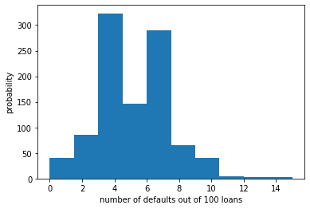

```python
# Seed random number generator
np.random.seed(42)

# Initialize the number of defaults: n_defaults
n_defaults = np.empty(1000)

# Compute the number of defaults
for i in range(1000):
    n_defaults[i] = perform_bernoulli_trials(100,0.05)

# Plot the histogram with default number of bins; label your axes
_ = plt.hist(n_defaults)
_ = plt.xlabel('number of defaults out of 100 loans')
_ = plt.ylabel('probability')

# Show the plot
plt.show()
```

**Will the bank fail?**

1. Plot the number of defaults you got from the previous exercise, in your namespace as n_defaults, as a CDF.
2. If interest rates are such that the bank will lose money if 10 or more of its loans are defaulted upon,
3. what is the probability that the bank will lose money?

**Computing the ECDF**

```python
def ecdf(data):
    """Compute ECDF for a one-dimensional array of measurements."""
    # Number of data points: n
    n = len(data)

    # x-data for the ECDF: x
    x = np.sort(data)

    # y-data for the ECDF: y
    y = np.arange(1, len(x)+1) / n

    return x, y
```

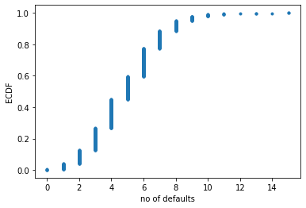

```
Probability of losing money = 0.022
```

```python
# Compute ECDF: x, y
x, y =ecdf(n_defaults)

# Plot the ECDF with labeled axes
plt.plot(x,y, marker='.',linestyle='none')
plt.xlabel('no of defaults')
plt.ylabel('ECDF')
# Show the plot
plt.show()

# Compute the number of 100-loan simulations with 10 or more defaults: n_lose_money
n_lose_money=np.sum(n_defaults>=10)

# Compute and print probability of losing money
print('Probability of losing money =', n_lose_money / len(n_defaults))

#As we might expect, we most likely get 5/100 defaults. But we still have about a 2% chance of getting 10 or more defaults out of 100 loans.
```